# White Wine Quality by Ferris Walkenford

After consideration the white wine dataset was chosen for the analysis. This data was chosen on the quality of the data and the main point of interest being clear. This analysis will consider the attributes in various qualities of wines.

# Univariate Plots Section

First an example of the data shape to better understand the frame that the data is created in.

```
## [1] 4898   13
```

This data has 4898 rows of information and 13 columns of categories.

```
## 'data.frame':    4898 obs. of  13 variables:
##  $ X                   : int  1 2 3 4 5 6 7 8 9 10 ...
##  $ fixed.acidity       : num  7 6.3 8.1 7.2 7.2 8.1 6.2 7 6.3 8.1 ...
##  $ volatile.acidity    : num  0.27 0.3 0.28 0.23 0.23 0.28 0.32 0.27 0.3 0.22 ...
##  $ citric.acid         : num  0.36 0.34 0.4 0.32 0.32 0.4 0.16 0.36 0.34 0.43 ...
##  $ residual.sugar      : num  20.7 1.6 6.9 8.5 8.5 6.9 7 20.7 1.6 1.5 ...
##  $ chlorides           : num  0.045 0.049 0.05 0.058 0.058 0.05 0.045 0.045 0.049 0.044 ...
##  $ free.sulfur.dioxide : num  45 14 30 47 47 30 30 45 14 28 ...
##  $ total.sulfur.dioxide: num  170 132 97 186 186 97 136 170 132 129 ...
##  $ density             : num  1.001 0.994 0.995 0.996 0.996 ...
##  $ pH                  : num  3 3.3 3.26 3.19 3.19 3.26 3.18 3 3.3 3.22 ...
##  $ sulphates           : num  0.45 0.49 0.44 0.4 0.4 0.44 0.47 0.45 0.49 0.45 ...
##  $ alcohol             : num  8.8 9.5 10.1 9.9 9.9 10.1 9.6 8.8 9.5 11 ...
##  $ quality             : int  6 6 6 6 6 6 6 6 6 6 ...
```

All columns are made of numbered data types with the exception of the “X” and “quality” columns.

```
##        X        fixed.acidity    volatile.acidity  citric.acid
##  Min.   :   1   Min.   : 3.800   Min.   :0.0800   Min.   :0.0000
##  1st Qu.:1225   1st Qu.: 6.300   1st Qu.:0.2100   1st Qu.:0.2700
##  Median :2450   Median : 6.800   Median :0.2600   Median :0.3200
##  Mean   :2450   Mean   : 6.855   Mean   :0.2782   Mean   :0.3342
##  3rd Qu.:3674   3rd Qu.: 7.300   3rd Qu.:0.3200   3rd Qu.:0.3900
##  Max.   :4898   Max.   :14.200   Max.   :1.1000   Max.   :1.6600
##  residual.sugar     chlorides       free.sulfur.dioxide
##  Min.   : 0.600   Min.   :0.00900   Min.   :  2.00
##  1st Qu.: 1.700   1st Qu.:0.03600   1st Qu.: 23.00
##  Median : 5.200   Median :0.04300   Median : 34.00
##  Mean   : 6.391   Mean   :0.04577   Mean   : 35.31
##  3rd Qu.: 9.900   3rd Qu.:0.05000   3rd Qu.: 46.00
##  Max.   :65.800   Max.   :0.34600   Max.   :289.00
##  total.sulfur.dioxide    density             pH          sulphates
##  Min.   :  9.0        Min.   :0.9871   Min.   :2.720   Min.   :0.2200
##  1st Qu.:108.0        1st Qu.:0.9917   1st Qu.:3.090   1st Qu.:0.4100
##  Median :134.0        Median :0.9937   Median :3.180   Median :0.4700
##  Mean   :138.4        Mean   :0.9940   Mean   :3.188   Mean   :0.4898
##  3rd Qu.:167.0        3rd Qu.:0.9961   3rd Qu.:3.280   3rd Qu.:0.5500
##  Max.   :440.0        Max.   :1.0390   Max.   :3.820   Max.   :1.0800
##     alcohol         quality
##  Min.   : 8.00   Min.   :3.000
##  1st Qu.: 9.50   1st Qu.:5.000
##  Median :10.40   Median :6.000
##  Mean   :10.51   Mean   :5.878
##  3rd Qu.:11.40   3rd Qu.:6.000
##  Max.   :14.20   Max.   :9.000
```

This shows the lowest fixed acidity as 3.8 g/dm^3 and the highest at 14 g/dm^3. The sugar also had a content range of 0.6 to 65.8 g/l. The combination of the these two discrepencies may show the distinct attributes of quality ratings. The quality ranges between 3 and 9 with an average quality of 5.878.

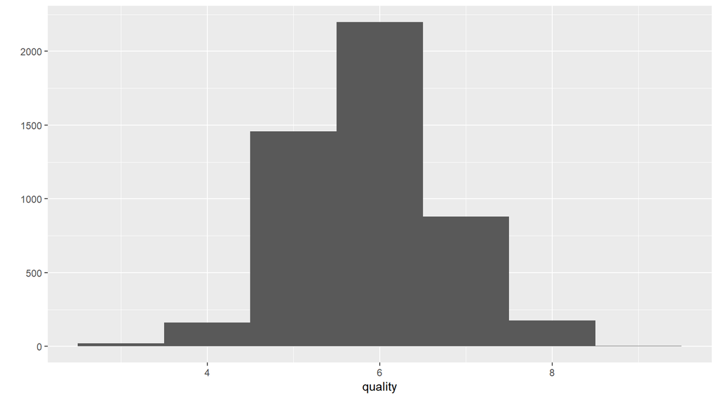

A histogram of the ratings reveals a relatively normal distribution. This was to be expected

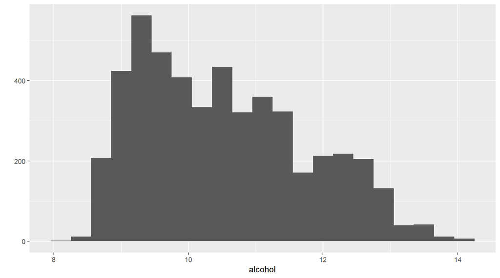

This data shows that the alcohol content was skewed to the right side.

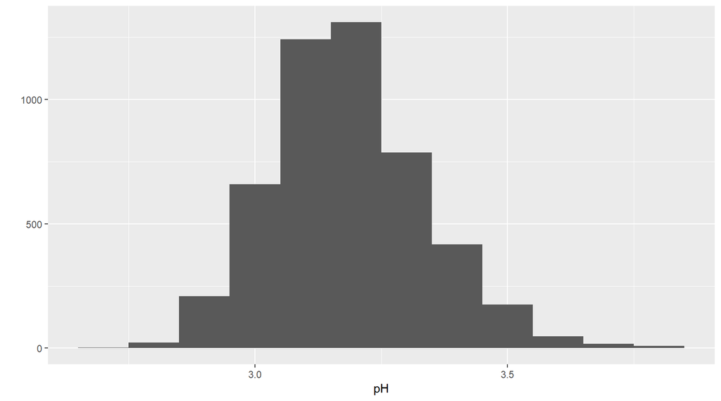

The pH(acidity) content appears to be normally distributed. The mean of the pH appears to be just below the 3.25. The summary shows the mean at 3.18. This is a relatively acidic drink well bell the pH of a neutral 7.

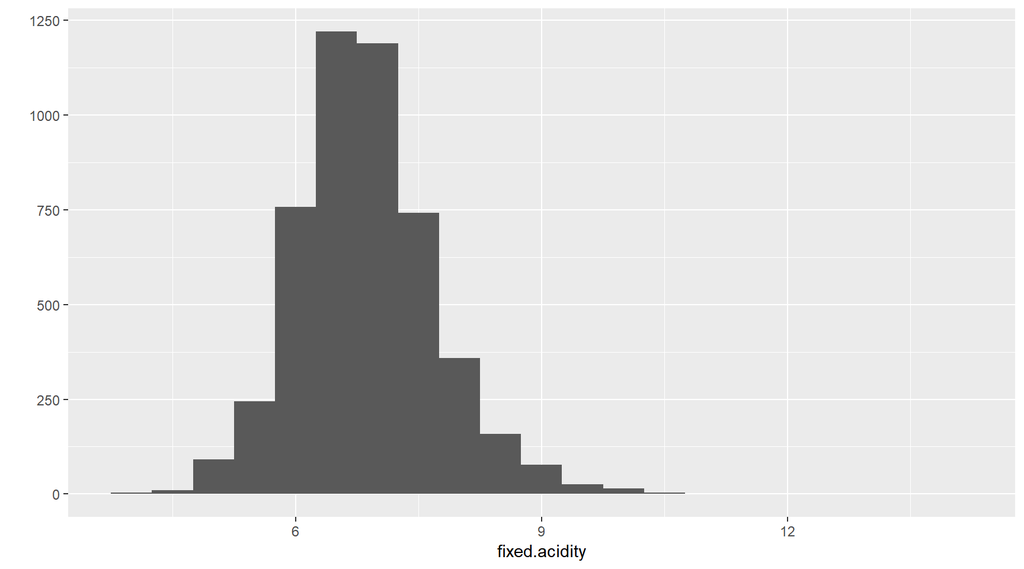

Fixed acidity is showing normal distribution with the mean around the 7 g/dm^3.

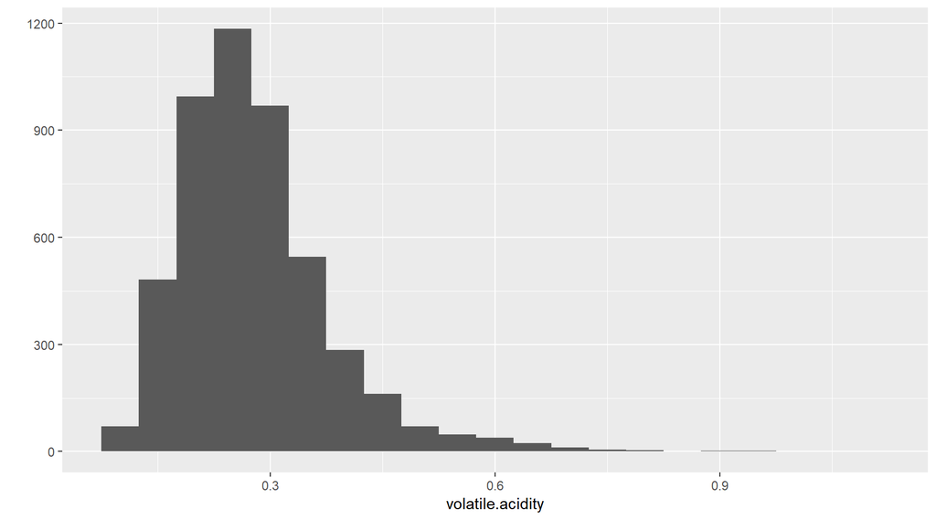

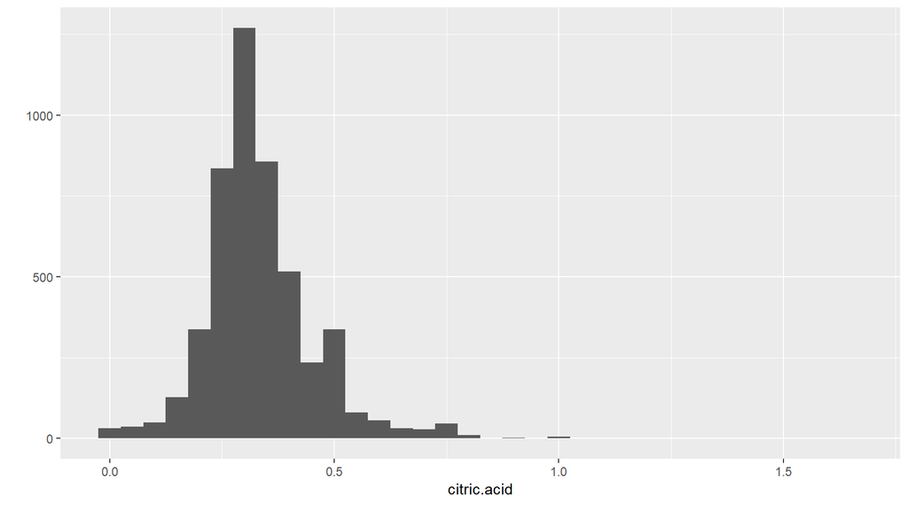

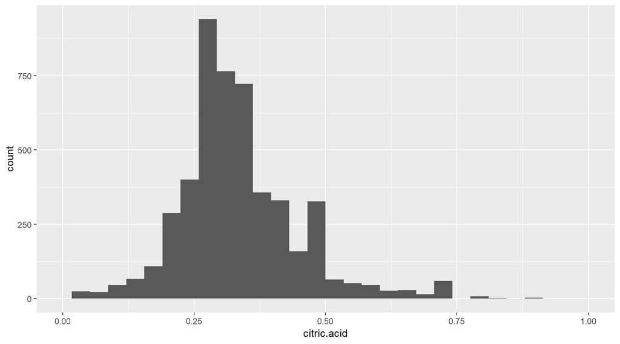

The citric acid looks like a normal distribution with a handful of anomalies skewing the tail to the right. For a more detailed view of the histogram a limit of the x-axis was added to a second histogram. With the second histogram the there was still a skew.

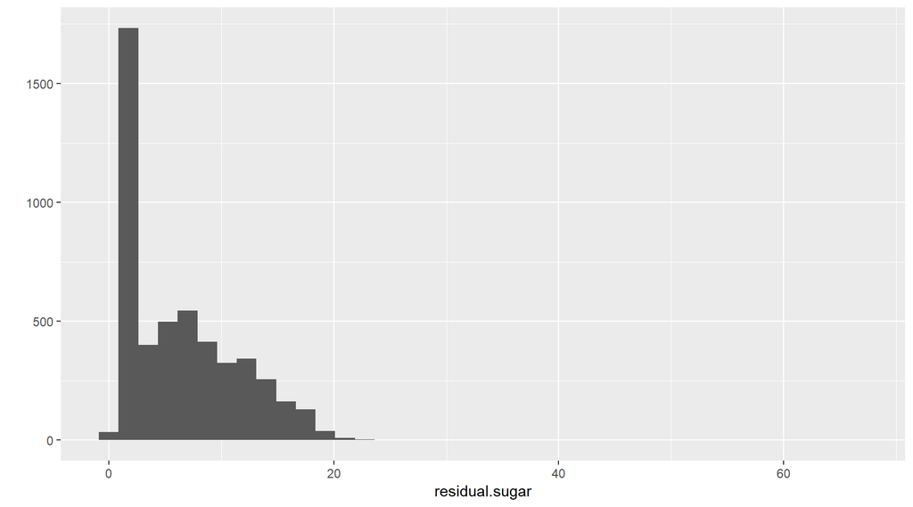

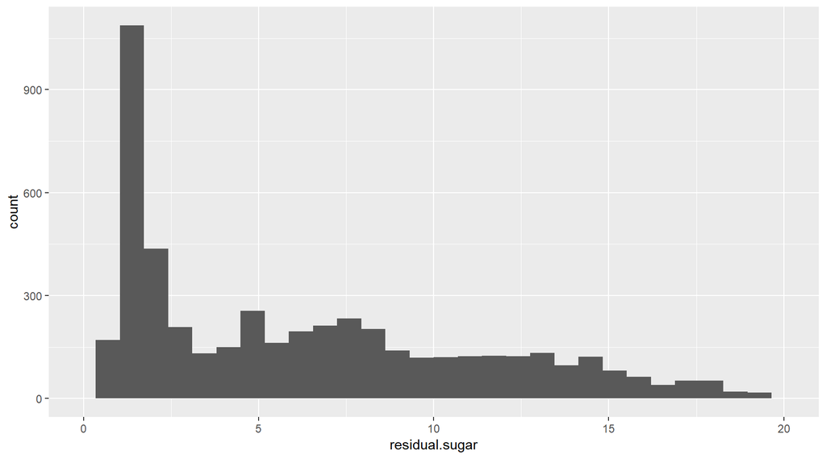

The residual sugar is also skewed to the right. This skewing is the most drastic of the results. The initial histagram had a similar view to the Citric Acid. A 95% confidence interval was added to show the more specifc trend in the wines.

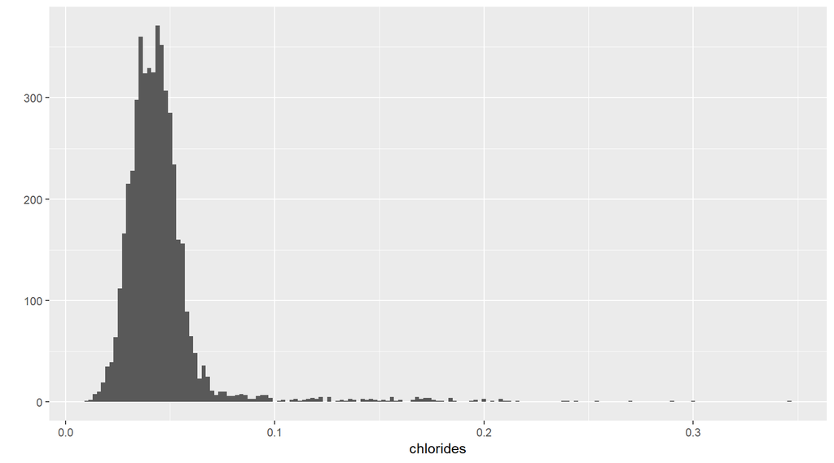

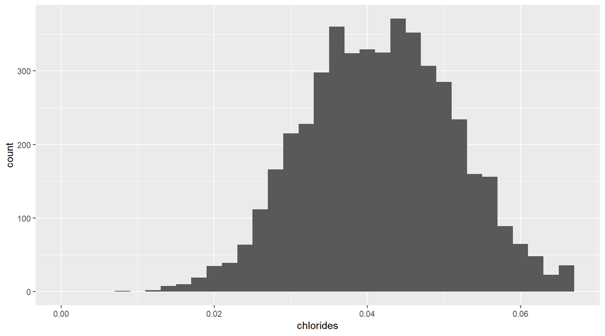

Initial Chloride viewing showed a very skewed tail. When removing the 5% of extreme cases the resulting views were much more normally distributed. The Extreme case cases made removing the 5% outliers would provide a much more balanced view.

# Univariate Analysis

### What is the structure of your dataset?

This dataset has 4898 rows and 13 columns.

### What is/are the main feature(s) of interest in your dataset?

This analysis is to revolve around the datatypes and how they relate to the quality rating

### What other features in the dataset do you think will help support your investigation into your feature(s) of interest?

Comparing the Acidity, Alcohol, Chlorides and the Sugar levels lead to correlative factor in the rating. This may show how the sweetness and the vingegar relation to quality.

### Did you create any new variables from existing variables in the dataset?

No new variables were created for the analysis.

### Of the features you investigated, were there any unusual distributions? Did you perform any operations on the data to tidy, adjust, or change the form of the data? If so, why did you do this?

Limiting the Citric Acid and Residual Sugar removed the extreme anomalies and provided a zoomed in/clearer representation on the data. I also limited the viewing of the histogram on the Cholides to 95% accuracy on the histogram this altered the view and showed a much more normal distribution.

# Bivariate Plots Section

```
##  [1] "fixed.acidity"        "volatile.acidity"     "citric.acid"
##  [4] "residual.sugar"       "chlorides"            "free.sulfur.dioxide"
##  [7] "total.sulfur.dioxide" "density"              "pH"
## [10] "sulphates"            "alcohol"              "quality"
```

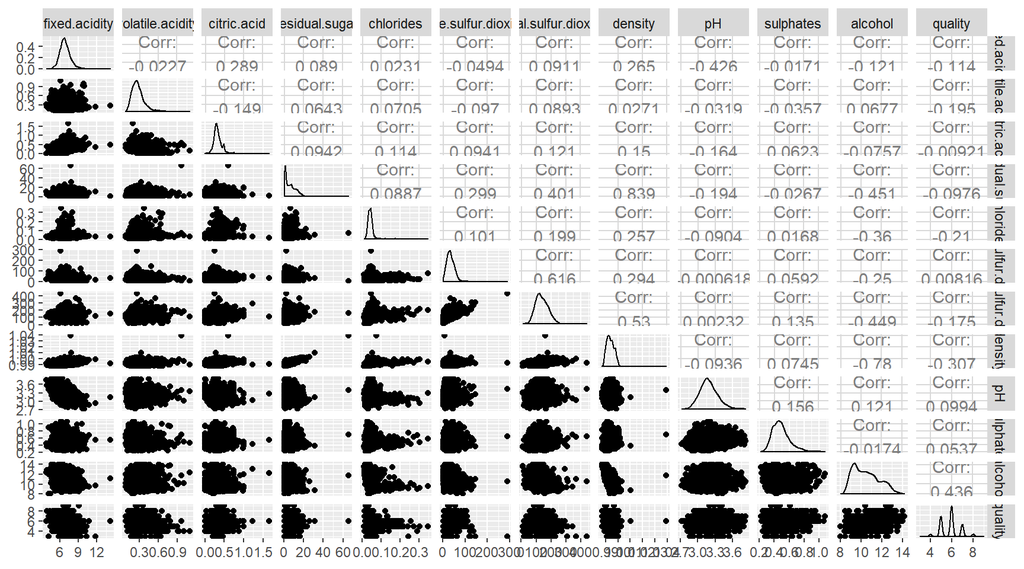

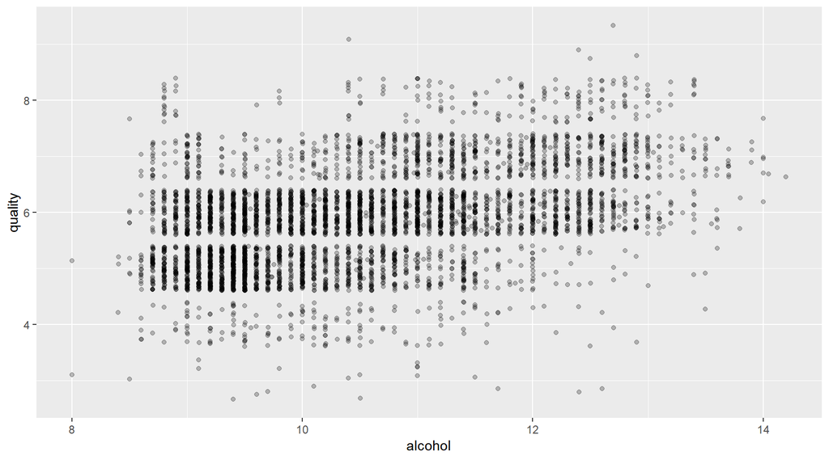

This shows more thicker lines around the lower alcohol content and quality but it is still rather messy to extrapolate the differences between the qualities.

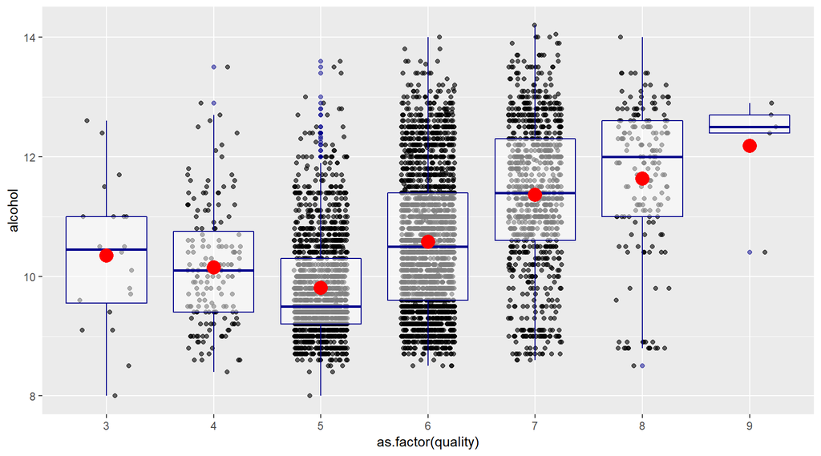

The strength of the alcohol does appear to have a relationship with quality.

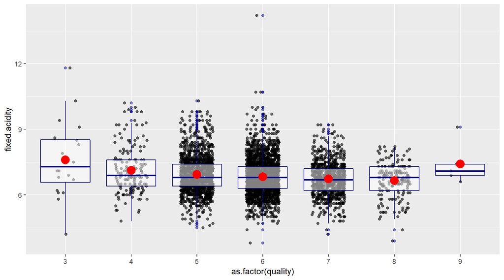

There does not appear to be a consistent trend when comparining the mean fixed acids to the quality.

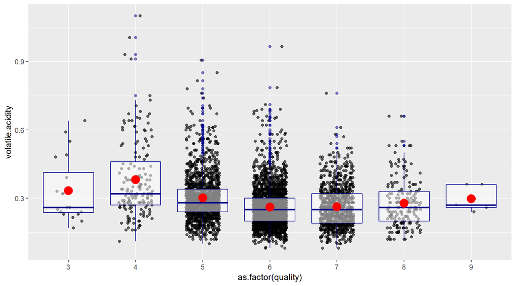

The mean volatile acids does not have a consitent trend with the quality.

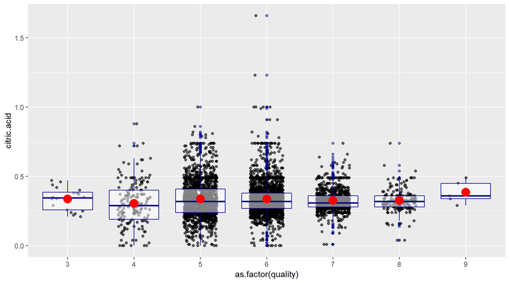

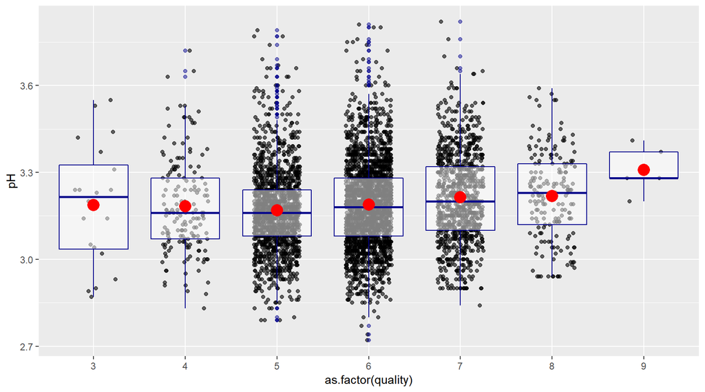

There does appear to be an acidity preference when looking at the quality ratings. The more basic the beverage the more likely to be rated higher

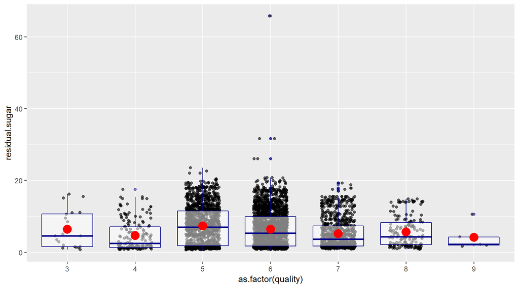

The Mean amount of the sugars by quality did not have a major effect on the rating of the quality.

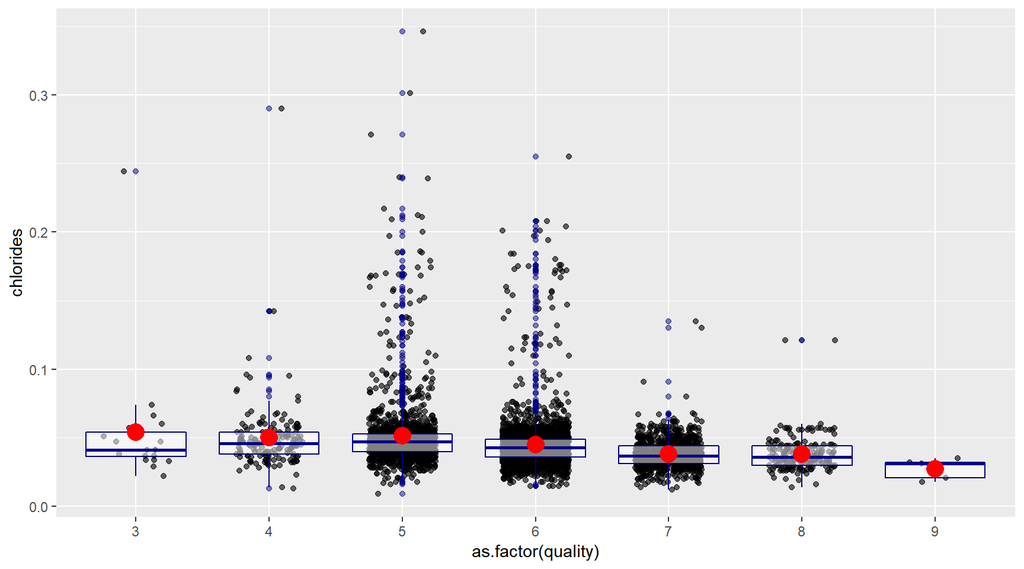

There does appear to be a negative trend when looking at the rating compared to the salt content.

# Bivariate Analysis

### Did you observe any interesting relationships between the other features (not the main feature(s) of interest)?

Density was the second strongest correlation with the quality rating in the data.

### What was the strongest relationship you found?

Alcohol Content was the highest likelihood to correlate to a higher quality rating.

# Multivariate Plots Section

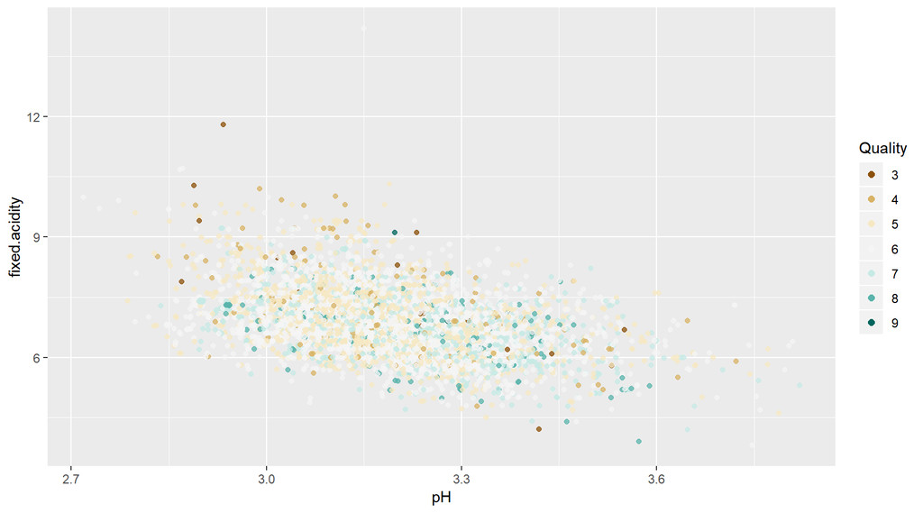

The data shows that the higher the quantity in fixed acidity ingredients; the lower the pH and the higher in acidity. This continues the expected trend in the higher rated wines being lower in acidity. There are enough outliers to recognize that the relationship is not particularly strong.

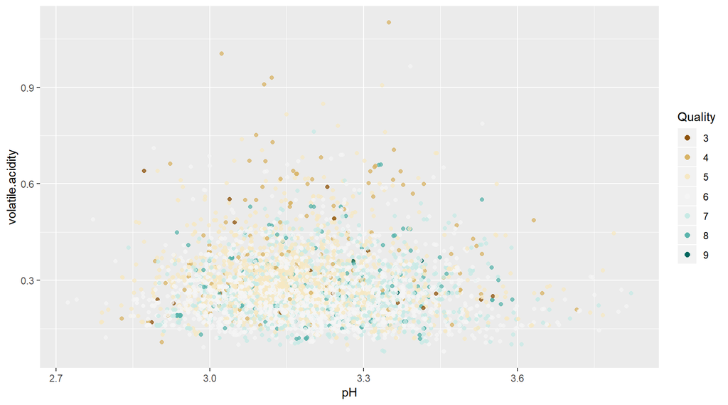

This graph showed the results of the Volatile Acid Ingredient do not follow any particular trend. The exception being the higher than normal average got low scores. The amount of Volatile ingredients does not appear to have majorly affected the acidity.

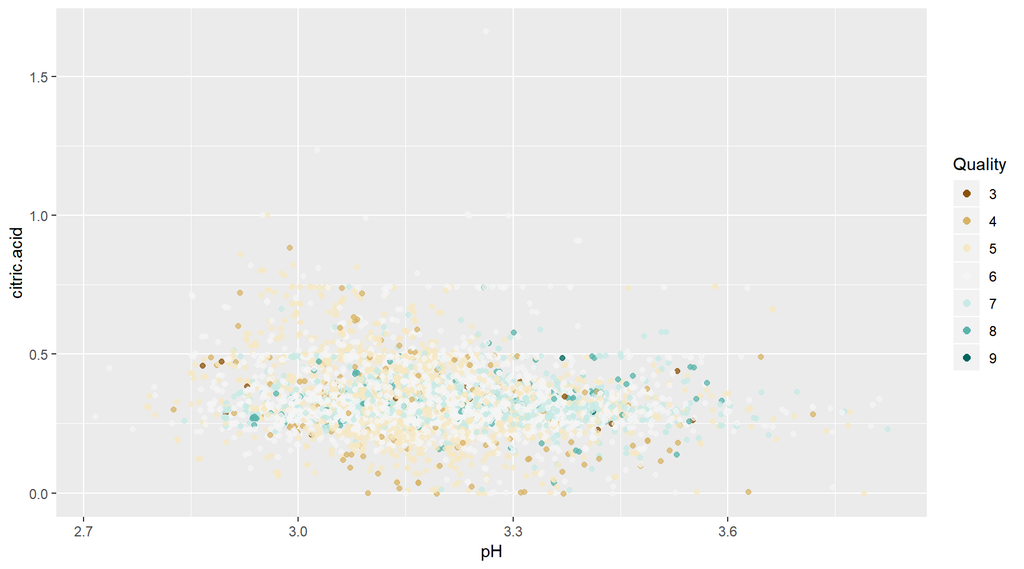

It does appear that a balance is needed between .25 and .3 g/dm^3 for the current wines to consistently score high.The volume of citric acid does not appear related to the acidity of the wine.

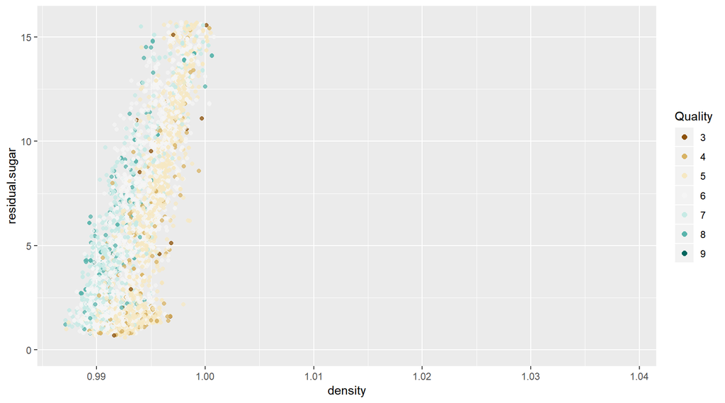

This graph is showing that the amount of residual sugar does affect the density. It is also showing that the less sugar and the less dense, the greater more likely for a higher rating.

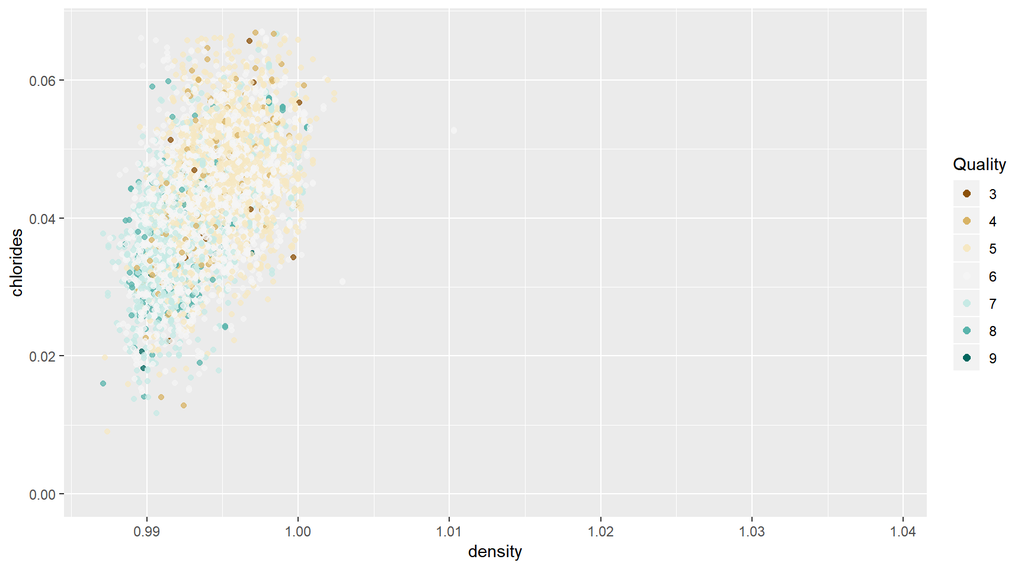

This graph is showing that the amount of salt does affect the density. It is also showing that the less salt and the less dense, the greater more likely for a higher rating.

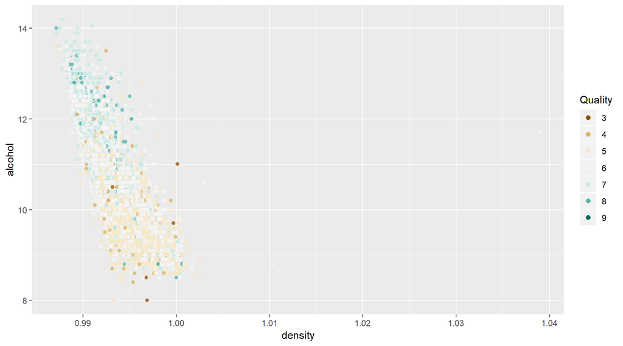

It does appear that the higher the alcohol content the less dense the wine. It also appears that the more dense the lower the quality rating.

# Multivariate Analysis

### Talk about some of the relationships you observed in this part of the investigation. Were there features that strengthened each other in terms of looking at your feature(s) of interest?

Alcohol is a lower density liquid. It would make sense with the previous statistics that the rating would trend in the way that it did.

### Were there any interesting or surprising interactions between features?

It was surprising that there was no strong relationship between acidity and the volatile acidic ingredient levels. It is interesting that the two more popular ingredients in diets, sugar and salt have a negative relationship with the quality of the wine.

### OPTIONAL: Did you create any models with your dataset? Discuss the strengths and limitations of your model.

# Final Plots and Summary

### Plot One

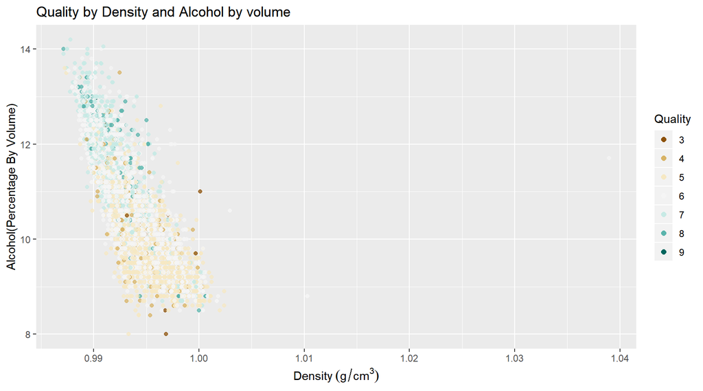

### Description One

This plot was chosen because it shows the relationship between density of water and alcohol. It also shows the relationship in the level of alcohol and density and the quality of the wines. Showing that the more dense and lower alcohol content the farther down the rating scale the wine fell.

### Plot Two

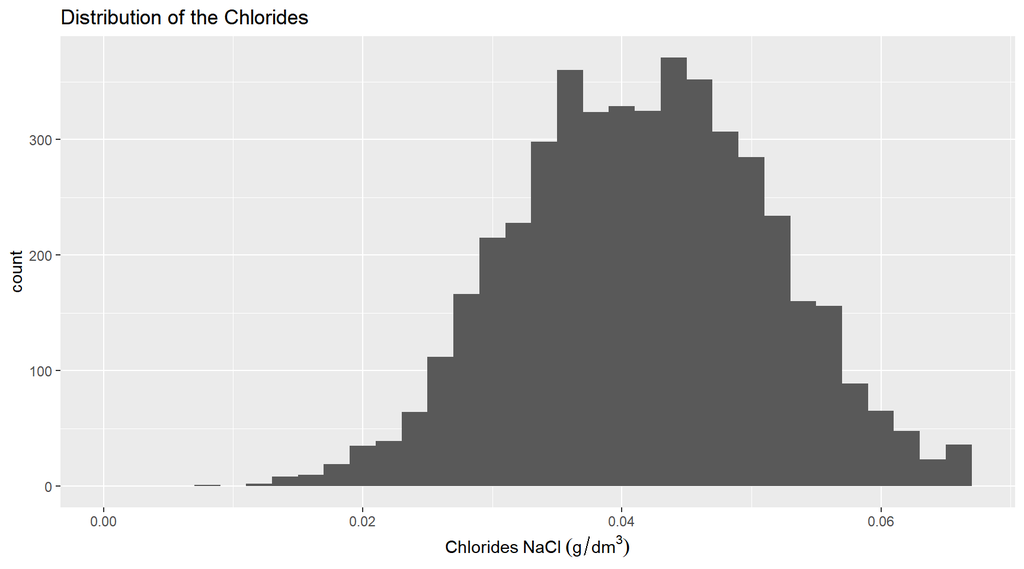

### Description Two

This plot shows the distrubition of the salt content in the wines when limiting the amount anaolies. The interval chosen was the 95% percentile. This was chosen to keep the average data intact when the anaomalies appeared to skew the distribution. After limiting the histogram the distribution appeared relatively normal.

### Plot Three

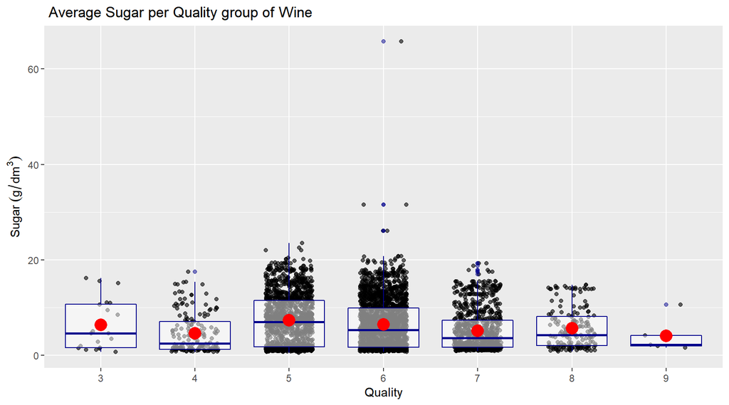

### Description Three

# Reflection

This was particurally more challenging than expected. I started off attempting a self selected dataset, but due to time constraints I was unable tidy the dataset. When working through this dataset, I had a couple of stumbles through adding the coloring. Limiting the Scope of the histograms was not something that I anticipated. When the anomolaies were minor I kept the data in tact and enhanced the view with a basic limit function. When there appear to be possible skewing of the data with anamolies I used the 95% confidence to remove the data and present a more true to the trend view of the wines. I did have a couple of surprises in that I would have thought the increase in sugar or the increase in salt would have led to an increase in the ratings.